[figure not shown]

# Compras en tiempos de COVID-19

Los siguientes análisis abordan las compras realizadas durante 2020 que están relacionadas con la emergencia sanitaria COVID-19, el objetivo es conocer el comportamiento de este tipo de adquisiciones, indagando sobre los principales compradores, proveedores y productos comprados para enfrentar la crisis. Para establecer si una compra fue hecha para enfrentar la emergencia, buscamos en sus descriptores indicios que nos permitan determinar este vínculo, pero este trabajo se establece sobre el supuesto de que dichos indicios existen, cuestión que no siempre es así, por ello invitamos a las autoridades a cargo de la coordinación de esta crisis, a que instuyan a los diferentes organismos del Estado a generar las marcas que permitan identificar las compras correspondientes

`Definición Inicial: Se considera compra relacionada con la emergencia sanitaria (CORONAVIRUS) aquellas adquisciones cuyas descripcion o nombre de la orden de compra (OC) contengan las palabras "CORONA + VIRUS" + o "COVID".`

`Datos del proceso: El reporte se encuentra con datos cargados a la fecha``16-04-2020``y la última OC de COVID detectada tiene fecha de envío``16-04-2020``, a la fecha de carga se cuentan``10.776``órdenes de compra relacionadas con COVID-19, de acuerdo a la definición inicial, estas suman un monto total de``$138.391``millones de pesos`

Antes de pasar a los análisis específicos te presentamos algunos datos estadísticos generales para conocer el comportamiento y avance de las compras realizadas por el Estado para enfrentar la pandemia (siempre que cumplan con la definición inicial)

[output not shown]

## Principales órdenes de compra a la fecha

La siguiente tabla presenta las 10 órdenes de compra relacionadas a la emergencia, de acuerdo a la **definición inicial**, ordenadas desde el mayor al menor monto.

|  | codigoOC | Fecha Envio | modalidad | Servicio | Proveedor | montoMillones |
| --- | --- | --- | --- | --- | --- | --- |
| 1 | 1082417-11-SE20 | 2020-03-13 | Trato Directo | Subsecretaría De Salud Pública | Comercial Kendall Chile Ltda | 11.550 |
| 2 | 1079394-60-SE20 | 2020-03-19 | Trato Directo | Subsecretaría De Salud Pública | Bioquimica.Cl S.A. | 7.500 |
| 3 | 1082417-13-CM20 | 2020-03-16 | Convenio Marco | Subsecretaría De Salud Pública | Arquimed Innovación Spa | 4.450 |
| 4 | 1082417-37-SE20 | 2020-03-23 | Trato Directo | Subsecretaría De Salud Pública | Andover Alianza Médica S. A. | 3.088 |
| 5 | 1082417-43-CM20 | 2020-03-27 | Convenio Marco | Subsecretaría De Salud Pública | Dispositivos Médicos S.P.A | 2.518 |
| 6 | 1082417-42-SE20 | 2020-03-27 | Trato Directo | Subsecretaría De Salud Pública | Hemisferio Sur Sa | 2.138 |
| 7 | 1082417-26-CM20 | 2020-03-18 | Convenio Marco | Subsecretaría De Salud Pública | Arquimed Innovación Spa | 1.606 |
| 8 | 1082417-18-CM20 | 2020-03-16 | Convenio Marco | Subsecretaría De Salud Pública | Stryker Corporation Chile Y Compania Ltda | 1.593 |
| 9 | 1079394-86-SE20 | 2020-03-30 | Trato Directo | Subsecretaría De Salud Pública | Life Technologies Chile Spa | 1.448 |
| 10 | 1079394-110-SE20 | 2020-04-15 | Trato Directo | Subsecretaría De Salud Pública | Servicios Médicos Y Clínicos Ultra Sound Techn... | 1.411 |

## Principales Compradores

La siguiente tabla presenta los principales compradores que cumplen con la **definición inicial**, la columna monto en millones corresponde a la suma total del monto de las órdenes de compras relacionadas a la emergencia que fueron adquiridas por el servicio, mientras que el porcentaje corresponde a la fracción que representa ese total de compras del servicio, sobre el total de adquisiciones relacionadas con la emergencia sanitaria

|  | Servicio | Monto en millones | porcentaje | montoMillones |
| --- | --- | --- | --- | --- |
| 1 | Subsecretaría De Salud Pública | 60480.0 | 43.7 | 60.480 |
| 2 | Servicio De Salud Nuble | 4197.0 | 3.0 | 4.197 |
| 3 | Complejo Asistencial Dr. Victor Ríos Ruíz | 3244.0 | 2.3 | 3.244 |
| 4 | Hospital Doctor Hernán Henríquez Aravena | 3145.0 | 2.3 | 3.145 |
| 5 | Servicio De Salud Araucanía Sur | 3099.0 | 2.2 | 3.099 |
| 6 | Servicio De Salud Del Reloncaví | 2675.0 | 1.9 | 2.675 |
| 7 | Servicio De Salud Antofagasta | 2556.0 | 1.8 | 2.556 |
| 8 | Hospital De Puerto Montt | 2405.0 | 1.7 | 2.405 |
| 9 | Servicio De Salud Viña Del Mar - Quillota | 1773.0 | 1.3 | 1.773 |
| 10 | Hospital Regional De Antofagasta | 1611.0 | 1.2 | 1.611 |

## Principales Proveedores

La siguiente tabla presenta los principales proveedores que cumplen con la **definición inicial**, la columna monto en millones corresponde a la suma total del monto de las órdenes de compras relacionadas a la emergencia que fueron emitidas al proveedor, mientras que el porcentaje corresponde a la fracción que representa ese total de ventas del proveedor, sobre el total de adquisiciones relacionadas con la emergencia sanitaria.

|  | Proveedor | RUT Proveedor | Monto en millones | porcentaje |
| --- | --- | --- | --- | --- |
| 1 | Comercial Kendall Chile Ltda | 77.237.150-0 | 11.803 | 8.5 |
| 2 | Bioquimica.Cl S.A. | 76.563.320-6 | 7.651 | 5.5 |
| 3 | Arquimed Innovación Spa | 76.560.564-4 | 7.594 | 5.5 |
| 4 | Life Technologies Chile Spa | 77.453.910-7 | 5.528 | 4.0 |
| 5 | Andover Alianza Médica S. A. | 96.625.550-1 | 4.662 | 3.4 |
| 6 | Imp. Dist. Arquimed Ltda. | 92.999.000-5 | 3.780 | 2.7 |
| 7 | Hemisferio Sur Sa | 96.533.330-4 | 3.639 | 2.6 |
| 8 | Roche Chile Ltda. Roche Pharma | 82.999.400-3 | 2.955 | 2.1 |
| 9 | Bluemedical Ltda. | 76.116.604-2 | 2.624 | 1.9 |
| 10 | Dispositivos Médicos S.P.A | 76.573.521-1 | 2.546 | 1.8 |

## Modalidad de Compra

El siguiente corresponde al análisis del comportamiento de la modalidad de compra según día, y respondiendo siempre a la **definición inicial**

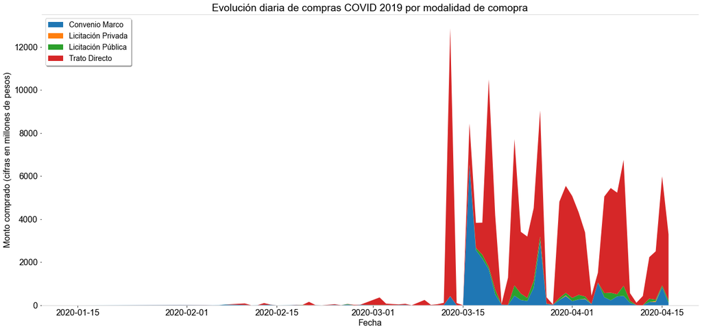

## Principales productos

La siguiente tabla presenta las compras que cumplan con la **definición inicial**, mostrando los productos que más se compraron, sus respectivos montos y el procentaje que representan sobre el total de compras de COVID-19. Los productos son el nivel más desagregado de categorías de productos de acuerdo a la clasificación ONU de productos. La tabla presenta los diez principales.

|  | Producto | Monto en millones | porcentaje |
| --- | --- | --- | --- |
| 1 | Mascarillas de aislamiento o quirófano para el... | 18.774 | 13.6 |
| 2 | Circuito de respiración o ventilador | 16.255 | 11.7 |
| 3 | Unidades de monitorización de flujo sanguíneo ... | 10.627 | 7.7 |
| 4 | Kits de ensayo parasitológicos o micológicos, ... | 7.597 | 5.5 |
| 5 | Ventiladores de cuidado intensivo pediátrico o... | 7.110 | 5.1 |
| 6 | Kits de ensayo de banco de sangre o suministros | 6.630 | 4.8 |
| 7 | Camillas de paciente o accesorios de camilla | 5.386 | 3.9 |
| 8 | Equipo para protección | 3.562 | 2.6 |
| 9 | Reactivos, soluciones o tinturas microbiológic... | 3.243 | 2.3 |
| 10 | Unidades de transporte o de señales vitales mó... | 2.382 | 1.7 |

### Gráfico de principales productos comprados para COVID, con sus respectivos compradores y proveedores

El siguiente gráfico presenta los 5 principales productos comprados que cumplan con la **definición inicial**, junto los principales compradores y proveedores, estos últimos de definieron enbase al monto de la transacción, solo se consideraron principales aquellas transaccione sobre los 100 millones de pesos. El gráfico permite ver las relaciones Comprador -> Productos -> Proveedor

[interactive chart not shown]